# stats306_ch04

A: There is no relationship b/w bill depth and length. Bill length flunctuates around 45mm on avg, regardless of bill depth.

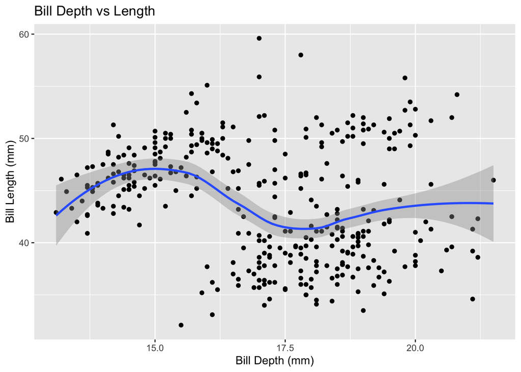

```r
ggplot(data=penguins,
       aes(x=bill_depth_mm,y=bill_length_mm))+
  geom_point()+
  geom_smooth()+
  labs(title="Bill Depth vs Length",
       x="Bill Depth (mm)",
       y="Bill Length (mm)")
```

Q: What happens if you make a scatterplot of species vs bill_depth_mm? Why is the plot not useful?

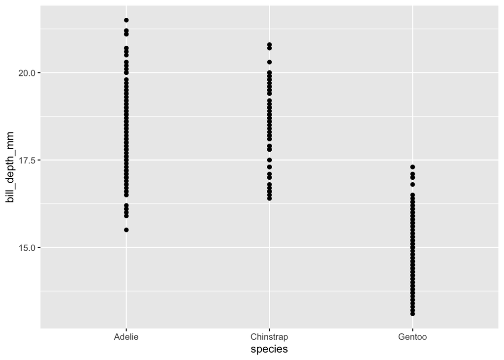

```r
ggplot(data=penguins,
       aes(x=species,y=bill_depth_mm))+
  geom_point()
```

Q: Why does the following give an error and how would you fix it?

A: Missing the aesthetics for x and y.

```r
# ggplot(data=penguins)+geom_point()
```

Q: What does the na.rm argument do in geom_point()? What is the default value of the argument? Create a scatterplot where you successfully use this argument set to TRUE.

A: The default is na.rm=FALSE, so don’t remove missings.

```r
ggplot(data=penguins,
       aes(x=species,y=bill_length_mm))+
  geom_point()
ggplot(data=penguins,
       aes(x=species,y=bill_length_mm))+
  geom_point(na.rm=TRUE)
```

[output not shown]

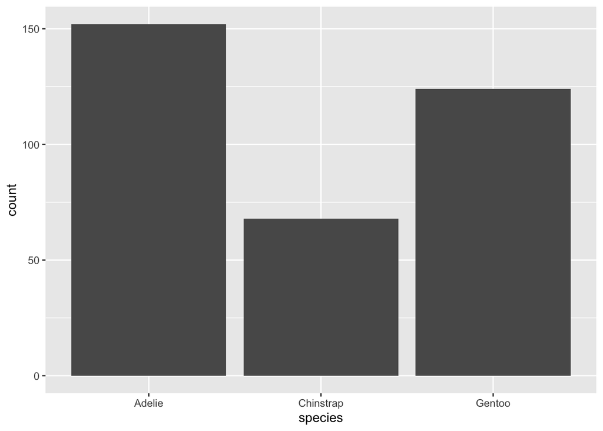

```r
ggplot(data=penguins,
       aes(x=species,y=bill_length_mm))+
  geom_point(na.rm=FALSE)
ggplot(penguins,aes(x=species))+geom_bar()
```

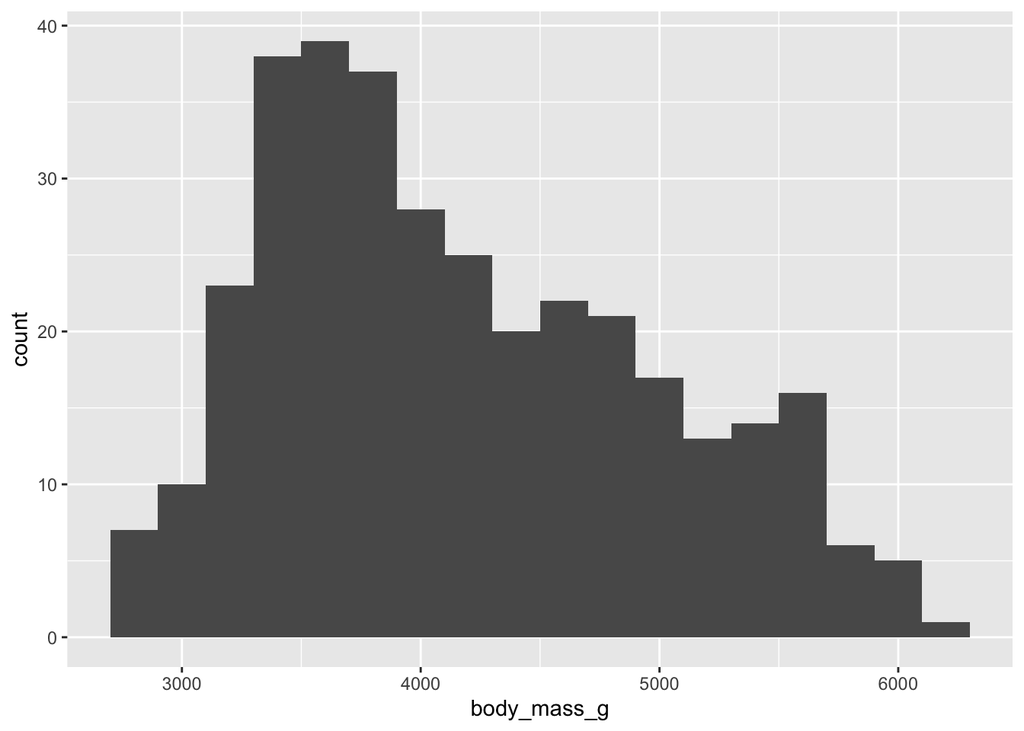

```r
ggplot(penguins,aes(x=body_mass_g))+geom_histogram(binwidth=200)
```

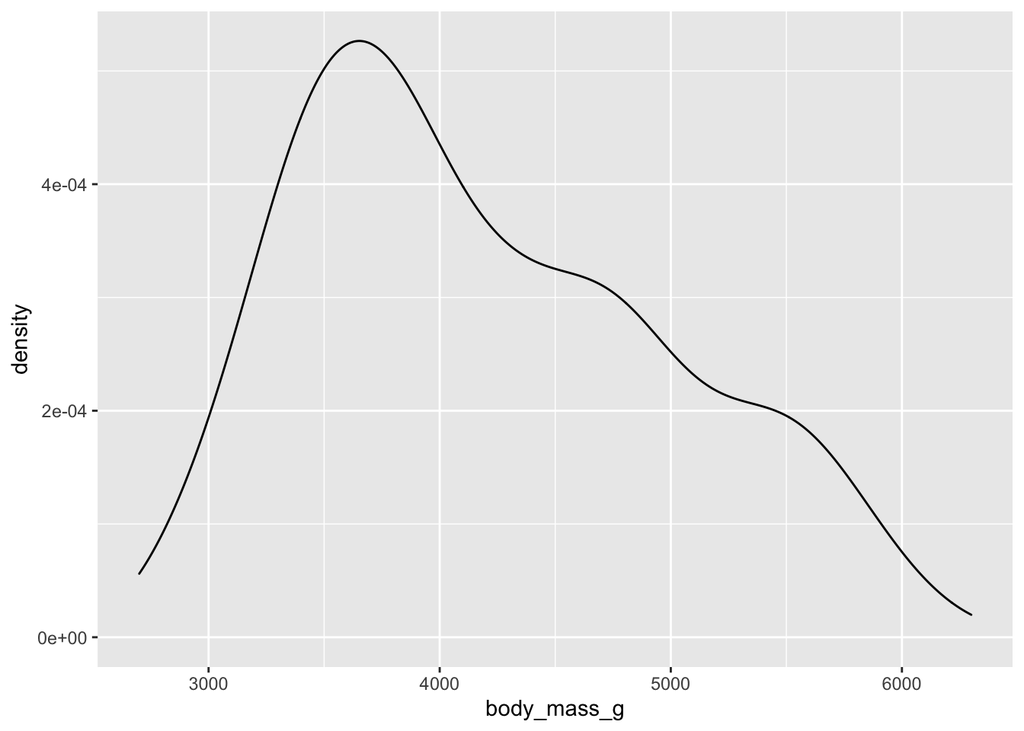

```r
ggplot(penguins,aes(x=body_mass_g))+geom_density()
```

Shows the distribution of body mass amongst penguins.

Q: Make a bar plot of species of penguins, where you assign species to the y aesthetic. How is this plot different?

A: Flips the axes of the graph around.

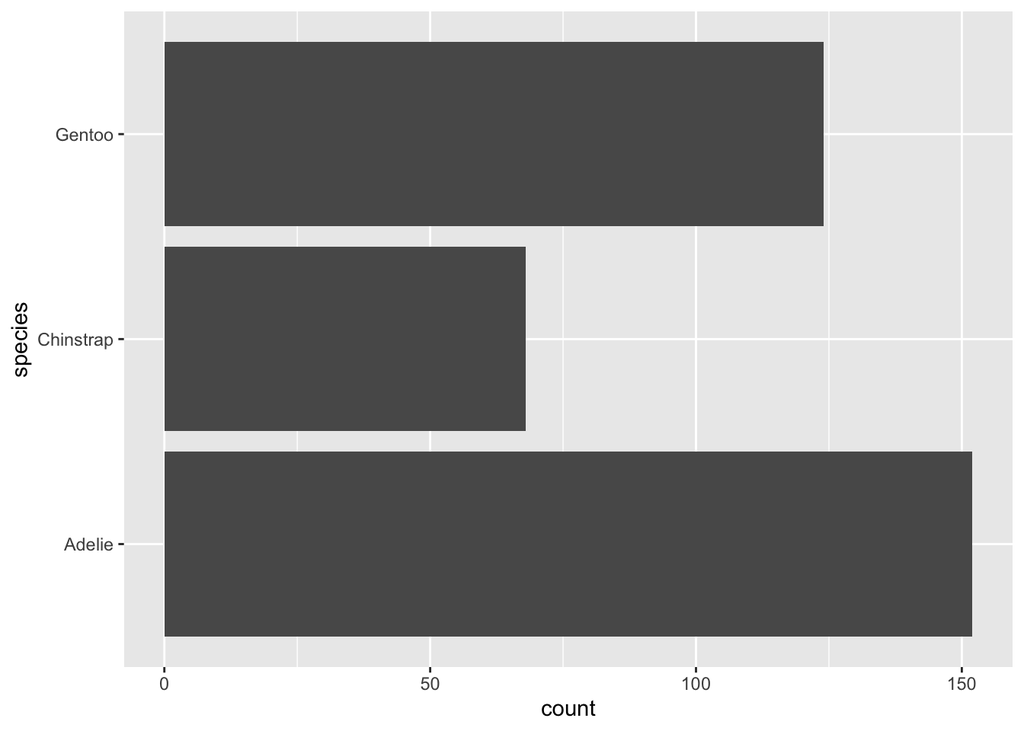

```r
ggplot(penguins,aes(y=species))+geom_bar()
```

Q: How are the following two plots different? Which aesthetic, color or fill, is more useful for changing the color of the bars?

A: Simply outlines the bars vs fills the bars. The ladder is more useful.

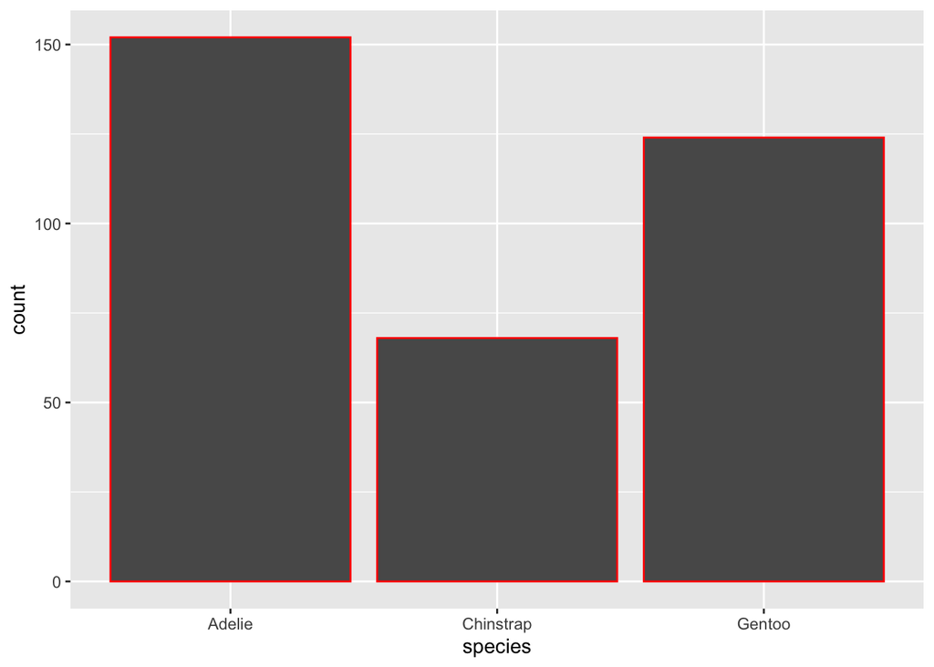

```r
ggplot(penguins,aes(x=species))+geom_bar(color="red")
```

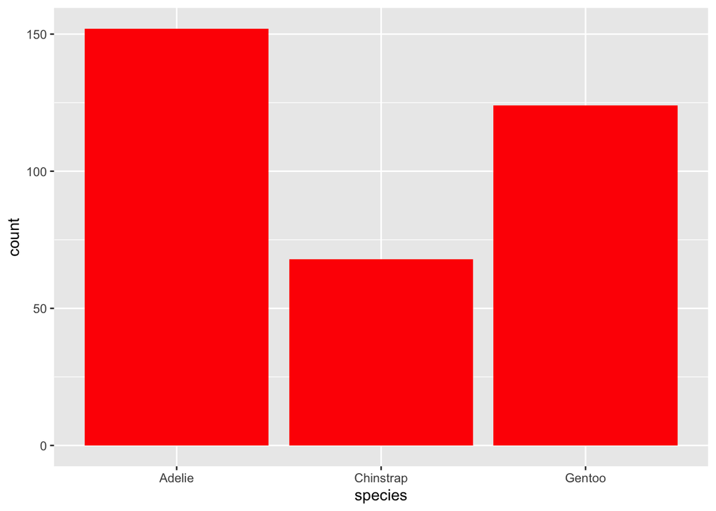

```r
ggplot(penguins,aes(x=species))+geom_bar(fill="red")
```

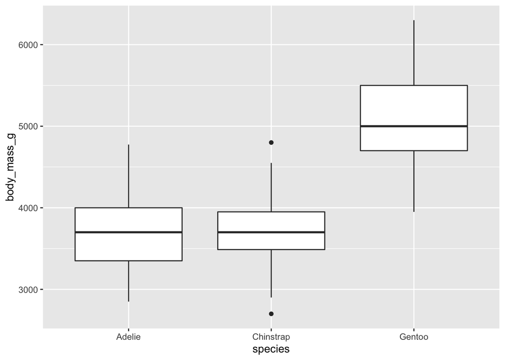

```r
ggplot(penguins,aes(x=species,y=body_mass_g))+geom_boxplot()
```

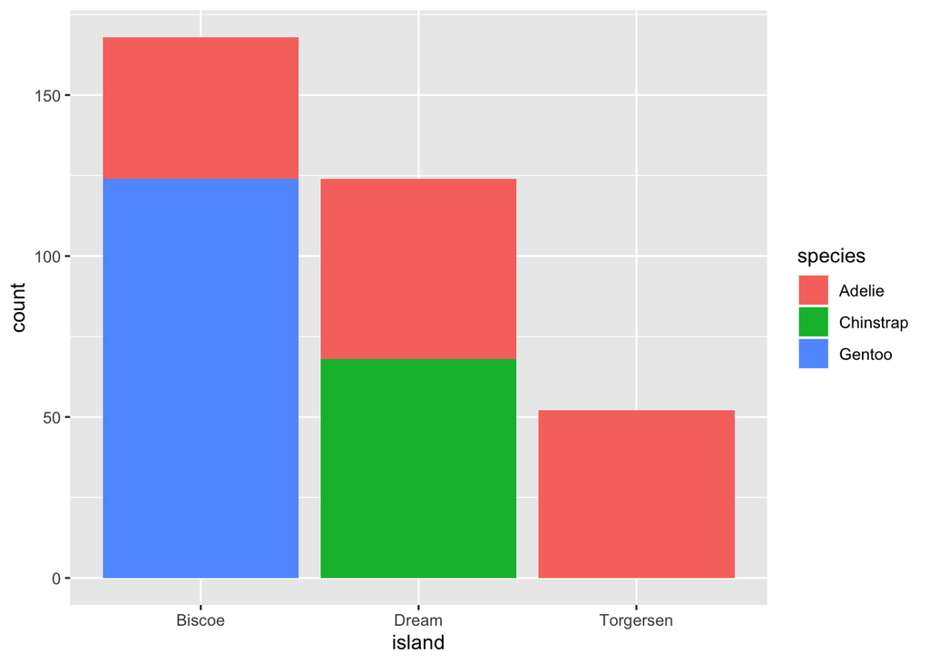

```r
ggplot(penguins,aes(x=island,fill=species))+geom_bar()
```

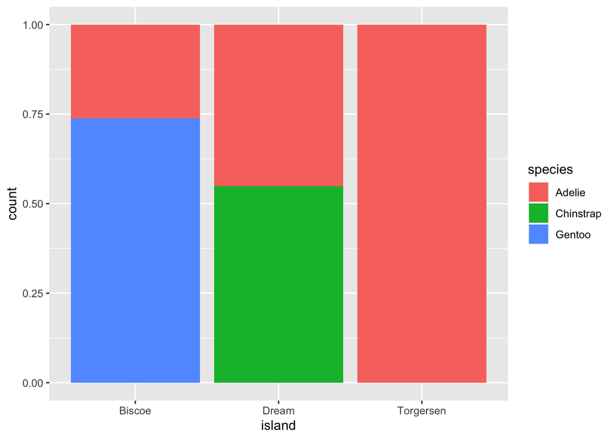

```r
ggplot(penguins,aes(x=island,fill=species))+geom_bar(position="fill")
```

IMPORTANT: Changes to proportions!

```r
ggsave("insertname.png") # saves the most recent plot
```